# Self-Driving Car Engineer Nanodegree

## Project: Build a Traffic Sign Recognition Classifier

In this notebook, a template is provided for you to implement your functionality in stages, which is required to successfully complete this project. If additional code is required that cannot be included in the notebook, be sure that the Python code is successfully imported and included in your submission if necessary.

> **Note**: Once you have completed all of the code implementations, you need to finalize your work by exporting the iPython Notebook as an HTML document. Before exporting the notebook to html, all of the code cells need to have been run so that reviewers can see the final implementation and output. You can then export the notebook by using the menu above and navigating to \n", "**File -> Download as -> HTML (.html)**. Include the finished document along with this notebook as your submission.

In addition to implementing code, there is a writeup to complete. The writeup should be completed in a separate file, which can be either a markdown file or a pdf document. There is a [write up template](https://github.com/udacity/CarND-Traffic-Sign-Classifier-Project/blob/master/writeup_template.md) that can be used to guide the writing process. Completing the code template and writeup template will cover all of the [rubric points](https://review.udacity.com/#!/rubrics/481/view) for this project.

The [rubric](https://review.udacity.com/#!/rubrics/481/view) contains "Stand Out Suggestions" for enhancing the project beyond the minimum requirements. The stand out suggestions are optional. If you decide to pursue the "stand out suggestions", you can include the code in this Ipython notebook and also discuss the results in the writeup file.

> **Note:** Code and Markdown cells can be executed using the **Shift + Enter** keyboard shortcut. In addition, Markdown cells can be edited by typically double-clicking the cell to enter edit mode.

## Step 0: Load The Data

```python
# Load pickled data in this code cell
import numpy as np
import pickle

# Folder to store training testing data
data_path = "./data/"

training_file = data_path + "train.p"
validation_file = data_path + "valid.p"
testing_file = data_path + "test.p"

print("Loading data from pickle file...  ", end='')
with open(training_file, mode='rb') as f:
    train = pickle.load(f)
with open(validation_file, mode='rb') as f:
    valid = pickle.load(f)
with open(testing_file, mode='rb') as f:
    test = pickle.load(f)

X_train, y_train = train['features'], train['labels']
X_valid, y_valid = valid['features'], valid['labels']
X_test, y_test = test['features'], test['labels']

# Use assert to inform us if X and y have different length
# (Quantity of data points)
assert(len(X_train) == len(y_train))
assert(len(X_valid) == len(y_valid))
assert(len(X_test) == len(y_test))
print("OK!")

# We concatenate training and validation data, It'll be splitted later
print("Combining training and validation data...  ", end='')
X_train_concat = np.concatenate((X_train, X_valid))
y_train_concat = np.concatenate((y_train, y_valid))
print("OK!")

# Do not use these anymore --> now we can see if we try to those incorrectly
X_train, y_train, X_valid, y_valid = None, None, None, None
```

```
Loading data from pickle file...  OK!
Combining training and validation data...  OK!
```

```python
# Load sign class numbers and descriptions from file
import csv
# Dictionary mapping where key is sign's class and value is it's description
sign_names = {}
# read classids and classid names from csv file
with open('signnames.csv', newline='') as csvfile:
    for row in csv.DictReader(csvfile, delimiter=','):
        sign_names[int(row['ClassId'])] = row['SignName']

def map_classids_to_names(classids, mapping):
    """
    This functions maps list of Class IDs to corresponding class description.

    Parameters
    ----------
    classids : list
        List of class ids to be mapped
    mapping : dictionary
        Dictionary where key is class id and value it's description

    Returns
    -------
    list
        List of corresponding class id names
    """
    return list(map(lambda classid: mapping[classid], classids))
```

## Step 1: Dataset Summary & Exploration

The pickled data is a dictionary with 4 key/value pairs:

- `'features'` is a 4D array containing raw pixel data of the traffic sign images, (num examples, width, height, channels).
- `'labels'` is a 1D array containing the label/class id of the traffic sign. The file `signnames.csv` contains id -> name mappings for each id.
- `'sizes'` is a list containing tuples, (width, height) representing the original width and height the image.
- `'coords'` is a list containing tuples, (x1, y1, x2, y2) representing coordinates of a bounding box around the sign in the image. **THESE COORDINATES ASSUME THE ORIGINAL IMAGE. THE PICKLED DATA CONTAINS RESIZED VERSIONS (32 by 32) OF THESE IMAGES**

Complete the basic data summary below. Use python, numpy and/or pandas methods to calculate the data summary rather than hard coding the results. For example, the [pandas shape method](http://pandas.pydata.org/pandas-docs/stable/generated/pandas.DataFrame.shape.html) might be useful for calculating some of the summary results.

### Provide a Basic Summary of the Data Set Using Python, Numpy and/or Pandas

```python
# Replace each question mark with the appropriate value.
# Use python, pandas or numpy methods rather than hard coding the results
import pandas as pd

# Number of training examples
n_train = len(X_train_concat)

# Number of testing examples.
n_test = len(X_test)

# What's the shape of an traffic sign image?
image_shape = X_train_concat[0].shape

# How many unique classes/labels there are in the dataset.
# Use pandas to get unique labels from y_train
df = pd.DataFrame({'label': y_train_concat})
n_classes = len(pd.unique(df.label))

# Print statistics of data set
print("Data set statistics")
print("Number of training examples =", n_train)
print("Number of testing examples =", n_test)
print("Image data shape =", image_shape)
print("Number of classes =", n_classes)

# Dataframe is not needed anymore
df = None
```

```
Data set statistics
Number of training examples = 39209
Number of testing examples = 12630
Image data shape = (32, 32, 3)
Number of classes = 43
```

### Include an exploratory visualization of the dataset

Visualize the German Traffic Signs Dataset using the pickled file(s). This is open ended, suggestions include: plotting traffic sign images, plotting the count of each sign, etc.

The [Matplotlib](http://matplotlib.org/) [examples](http://matplotlib.org/examples/index.html) and [gallery](http://matplotlib.org/gallery.html) pages are a great resource for doing visualizations in Python.

**NOTE:** It's recommended you start with something simple first. If you wish to do more, come back to it after you've completed the rest of the sections.

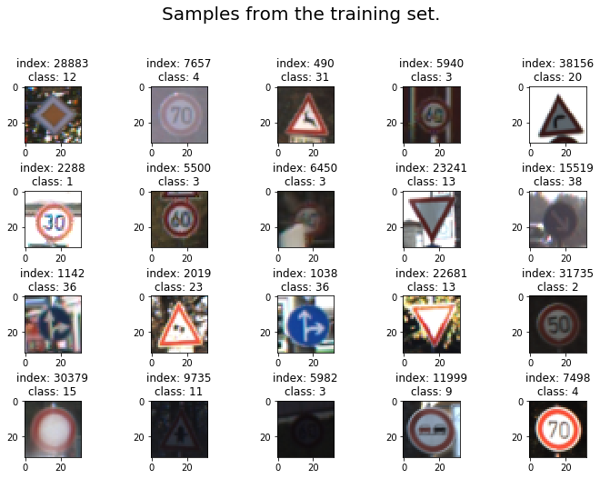

```python
# Code to show sample images from training set
import matplotlib.pyplot as plt
import random

# Visualizations will be shown in the notebook.
%matplotlib inline

# Initialize random number generator to generate always same set of samples
random.seed(a=1234)
number_of_samples = 20

# Here we generate list of random indexes which is used to pick up samples from the data set
sample_indices = [random.randint(0, len(X_train_concat)) for i in range(number_of_samples)]


def show_samples(indices, images, labels, cmap=None, title=None):
    """
    This functions shows sample images in 5 columns and number of rows
    adjusted according to number of samples. This function is capable of
    showing RGB images and grayscale images and user need to define color
    as 'gray' when grayscale images are shown.

    Parameters
    ----------
    indices : list
        List of sample indices which will be plotted. All the indices
        must be found from the images set
    images : list
        4D list of images (N, height, width, channels)
    labels : list
        List of string labels which correspond the label of 'indices'
    cmap : String
        Defines colol map
    title : string
        Title of the plot, shown above the pictures.

    """
    fig = plt.figure(figsize=(10, 8))
    fig.suptitle(title, fontsize=20, y=1.08)
    # i = is loop index; idx is sample index from "sample_indices"
    for i, idx in enumerate(indices):
        image = images[idx]
        a = fig.add_subplot(5, 5, i+1)
        if cmap == 'gray' or image.shape[2] == 1:
            # Force grayscale image, squeze() is needed to show grayscale images
            # with shape (x, y, 1)
            plt.imshow(image.squeeze(), cmap='gray')
        else:
            # Try defaults as no color map is given
            plt.imshow(image)
        a.set_title("index: " + str(idx) + "\nclass: " + str(labels[idx]))

    fig.tight_layout(w_pad=0.3, h_pad=0.5)

# Show few samples from the training set
show_samples(sample_indices, X_train_concat, y_train_concat, title="Samples from the training set.")
```

I also computed histogram in order to understand how class ids are distributed and below image we can see that some sign classes are over and underpresented. This could potentially cause problems on model training as there are alot of training samples for some classes and small training samples for some classes. We can also see that on given id the ratio of test and training set is about same on all class ids.

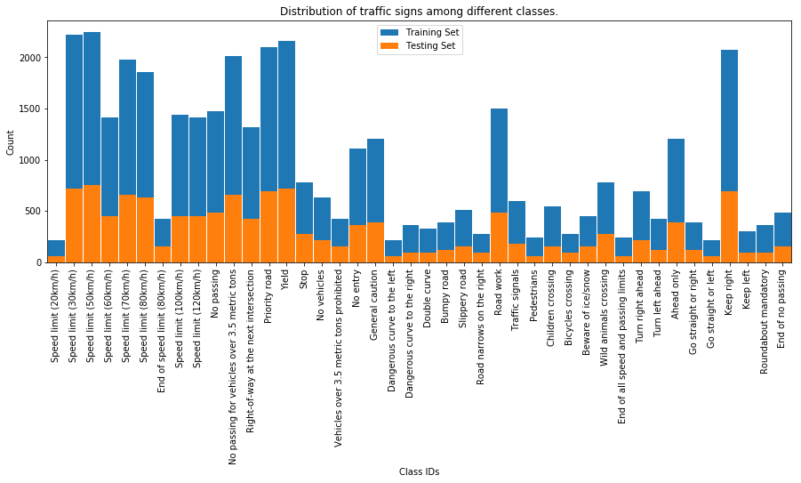

```python
# set figure size
fig = plt.figure(figsize=(15,5))

# Generate list of x-indexes which is used below on several places
classid_indexes = np.arange(0, n_classes)

# Compute histogram of class Ids
n_train, bins_train, patches_train = plt.hist(y_train_concat, classid_indexes,
                                              histtype="barstacked", stacked=False, rwidth=0.95)
n_test, bins_test, patches_est = plt.hist(y_test, classid_indexes,
                                          histtype="barstacked", stacked=False, rwidth=0.95)

# show histogram of traffic sign counts vs. class ids
plt.xlabel('Class IDs')
plt.ylabel('Count')
plt.title("Distribution of traffic signs among different classes.")

# Map class id's to corresponding names
labels = map_classids_to_names(classid_indexes, sign_names)

# Add x-axis ticks (class id names)
plt.xticks(classid_indexes+0.5, labels, rotation='90')

# Show which color is which set
plt.legend(('Training Set', 'Testing Set'))

# Sets x-axis limits
plt.xlim(0, n_classes-1)
plt.show()
```

## Step 2: Design and Test a Model Architecture

Design and implement a deep learning model that learns to recognize traffic signs. Train and test your model on the [German Traffic Sign Dataset](http://benchmark.ini.rub.de/?section=gtsrb&subsection=dataset).

The LeNet-5 implementation shown in the classroom at the end of the CNN lesson is a solid starting point. You'll have to change the number of classes and possibly the preprocessing, but aside from that it's plug and play!

With the LeNet-5 solution from the lecture, you should expect a validation set accuracy of about 0.89. To meet specifications, the validation set accuracy will need to be at least 0.93. It is possible to get an even higher accuracy, but 0.93 is the minimum for a successful project submission.

There are various aspects to consider when thinking about this problem:

- Neural network architecture (is the network over or underfitting?)
- Play around preprocessing techniques (normalization, rgb to grayscale, etc)
- Number of examples per label (some have more than others).
- Generate fake data.

Here is an example of a [published baseline model on this problem](http://yann.lecun.com/exdb/publis/pdf/sermanet-ijcnn-11.pdf). It's not required to be familiar with the approach used in the paper but, it's good practice to try to read papers like these.

### Pre-process the Data Set

Data should be optimized before it is fed to the neural network in order to:

1. Make neural network easier to train
   - For example if mean of data is far away from zero then learning algorithm need to do alot of work to fit data
2. Better performance
   - For example by using simple image processing we can make features more visible before feeding image to neural nel.
3. Generally make date more suitable for neural net

##### In my code there are following steps in pre-processing pipeline

Use the code cell (or multiple code cells, if necessary) to implement the first step of your project.

```python
# Preprocess the data here.
import numpy as np
from skimage import exposure
from multiprocessing import Process
import warnings

def preprocess_tensor_grayscale(tensor_4d):
    """
    This function makes simple RGB to grayscale conversion by calculating
    mean of color channels.
    NOTE! This function will not do visually accuracy
    grayscaling as it omits conversion weights for color channels.

    Parameters
    ----------
    tensor_4d : array
        Shape of the array is (N, img height, img width, 3)

    Returns
    -------
    array
        Grayscaled images, shape of array is (N, img height, img width, 1)
    """
    # TODO: replace below array sum and division operations with np.mean()
    # 0.0 in beginning is for changing data type to float
    X = (0.0 + tensor_4d[:, :, :, 0]
             + tensor_4d[:, :, :, 1]
             + tensor_4d[:, :, :, 2])
    X = X / 3
    X = X.reshape(X.shape + (1,))
    return X

def preprocess_tensor_adaptive_hist(tensor_4d):
    """
    This functions applies adaptive contras enchament to tensor.

    Parameters
    ----------
    tensor_4d : array
        4D tensor, shape should be (N, img_x, img_y, 1) or (N, img_x, img_y, 3)
    """
    shape = tensor_4d.shape
    # if image is grayscale then "squeeze" tensor to 3 dimensions (N, img_x, img_y)
    if shape[3] == 1:
        tensor_4d = np.reshape(tensor_4d, (shape[0], shape[1], shape[2]))

    def do(tensor, start, end):
        """This function handles the histogram adjustment. Functions do change in place."""
        for i in range(start, end):
            # , kernel_size=None, clip_limit=0.01, nbins=256, **kwargs)
            img = tensor[i]
            #print("Shape of tensor[{}] is".format(i), img.shape)
            processed = exposure.equalize_adapthist(img)
            #print("Shape of processed img is", processed.shape)
            return True
    nprocesses = 16  # number of processes to start, TODO: Change this to read number of cores or cpu threads
    batch_size = int(len(tensor_4d) / nprocesses)
    processes = []  # List to store launched processes
    start, end = 0, 0
    # Start processes

    for i in range(nprocesses):
        start = i * batch_size
        if i == (nprocesses - 1): # If last batch, then adjust end to cover all
            end = len(tensor_4d)
        else:
            end = start + batch_size
        p = Process(target=do, args=(tensor_4d, start, end))
        p.start()
        processes.append(p)
    # Join processes
    for i in processes:
        i.join()

    if shape[3] == 1:
        tensor_4d = np.reshape(tensor_4d, shape)
    return tensor_4d

def preprocess_tensor_adjust_mean(tensor_4d):
    """
    This functions adjusts image mean to very near zero.

    Parameters
    ----------
    tensor_4d : array
        Shape of the array is (N, img height, img width, 1)

    Returns
    -------
    array
         Array where individual images are adjusted to have zero mean.
         Shape of array is (N, img height, img width, 1)
    """
    # Calculate mean and reshape result array to shape (N, 1)
    mean = np.mean(tensor_4d, axis=(1, 2, 3))
    mean = mean.reshape(mean.shape + (1, ))
    # This is needed when we convert array back to it's original shape
    original_shape = tensor_4d.shape
    # Modify array shape so that we get shape which is (N, img_x*img_y)
    # i.ie input shape is (50,32,32,1) then we convert it to (50, 1024)
    # This will make it easier to apply following subtract operations on array
    X = np.reshape(tensor_4d, (original_shape[0], original_shape[1]**2))
    # Finally we can subtract mean from array to adjust
    # it's mean very near to zero
    X = np.subtract(X[:], mean)
    # Convert array shape (N, (img_x*img_y)) back to original tensor shape
    X = X.reshape(original_shape)
    return X

def preprocess_tensor_adjust_range(tensor_4d):
    """
    This functions adjusts the range of image to -1...1

    Parameters
    ----------
    tensor_4d : array
        Shape of the array is (N, img height, img width, 1).
        Input should have been adjusted to zero mean before feeding it to this function.

    Returns
    -------
    array
         Array where individual image values are limited within range -1...1
         Shape of array is (N, img height, img width, 1)
    """
    # Record tensor's original shape. It is needed when we convert array
    # back to it's original shape
    original_shape = tensor_4d.shape
    # Modify array shape so that we get shape which is (N, img_x*img_y)
    # i.ie input shape is (50,32,32,1) then we convert it to (50, 1024)
    # This will make it easier to apply following subtract operations on array
    reshaped = np.reshape(tensor_4d, (original_shape[0], original_shape[1]**2))
    # Find absolute maximum of each image
    maximum = np.amax(reshaped, axis=1, keepdims=True)
    minimum = np.amin(reshaped, axis=1, keepdims=True)
    abs_max = np.amax((np.abs(maximum), np.abs(minimum)), axis=0)
    # Adjust range to -1...1
    reshaped = reshaped / abs_max
    # Convert array shape (N, (img_x*img_y)) back to original tensor shape
    reshaped = reshaped.reshape(original_shape)
    return reshaped


def preprocess_tensor(tensor_4d):
    """
    This function preprocesses image tensor.
    1. convert RGB to grayscale
    2. Adjust mean to zero
    3. Limit range to -1...1

    Parameters
    ----------
    tensor_4d : array
        Original array with shape (N, img height, img width, 2).

    Returns
    -------
    array
         Preprocessed array. Shape of array is (N, img height, img width, 1)
    """
    # Only try to process RGB images, because most likely grayscaled images
    # are already preprocessed in this exercice
    if tensor_4d.shape[3] == 3:
        # Silence warning of dtype conversion, for some reason skimage is giving those
        with warnings.catch_warnings():
            warnings.simplefilter("ignore")
            tensor_4d = np.ndarray.astype(tensor_4d, dtype=np.uint8, casting='safe', copy=False)
            tensor_4d = preprocess_tensor_adaptive_hist(tensor_4d)
        tensor_4d = preprocess_tensor_grayscale(tensor_4d)
        tensor_4d = preprocess_tensor_adjust_mean(tensor_4d)
        tensor_4d = preprocess_tensor_adjust_range(tensor_4d)
    return tensor_4d
```

#### Pre-process Training, Validation and Test sets

Following code runs preprocessing pipeline to all data sets. Images shown below are from same traffic signs than in data exploration step.

```python
# Preprocess images here
print("Preprocessing Concatenated Training Data...    ", end='')
X_train_concat = preprocess_tensor(X_train_concat)
print("OK!")
print("Preprocessing Testing Data...     ", end='')
X_test  = preprocess_tensor(X_test)
print("OK!")
```

```
Preprocessing Concatenated Training Data...    OK!
Preprocessing Testing Data...     OK!
```

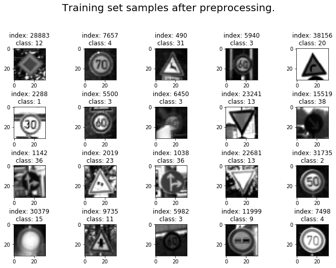

```python
# Show same samples as in color images above
show_samples(sample_indices, X_train_concat, y_train_concat, title="Training set samples after preprocessing.")
```

## Data augmentation

In this german traffic sign data set there are 34799 training samples available. We can augment data in order to prevent over fitting and traing model to generalize better. Anyhow data augmentation is relatively easy to do because in the simplest form it is just rotating, shifting, adding noise or other simple function. **And most importantly it is much more cheaper than collecting more training data.**

Here is brief explanation of data augmentation pipeline

1. Rotation: -20, -10, 10 and 20 degrees
2. Shifting: 5px to 8 directions

I would like to also experiment with these...

1. Warp image
2. Add salt&pepper and gaussian noise
3. Change contrast and lightness of image
4. Occlusions

### Rotation

First step in data augmentation is to rotate images by: -20, -10, 10 and 20 degrees and then add these 4 additional images to training set besides the original.

[figure not shown]

Data is first rotated

### Shifting

Next step is to shift images 5 pixels into each directions.

[figure not shown]

Images are shifted by 5 pixels

```python
# This code cell contains needed code for generating augmented images
import numpy as np
from scipy import ndimage
# For progress bar
from ipywidgets import FloatProgress, Text
from IPython.display import display


# Define whether we load augmented images from pickle file, This saves several minutes
GENERATE_AUGMENTED_DATA = False
# Set to true if you want to load augmented training data from file
LOAD_AUGMENTED_FROM_FILE = True


def augment_data(x, y, progressbar):
    """
    This function augments training data by doing following transformations
    - Rotate image -20, -10, +10, +20 degrees
    - Shift image 5 pixels in 8 directions

    WARNING! it'll take long time to run this function with data sets more than few hundred samples.
    TODO: Optimize data augmentation, changing this to a generator would be great as it is needed in next project
    """
    x_rotated, y_rotated = [], []
    xy_shifts = [( 0, 0,0), ( 0,-5,0), ( 0,5,0),
                 (-5,-5,0), (-5, 0,0), (-5,5,0),
                 ( 5,-5,0), ( 5, 0,0), ( 5,5,0)]
    rotations = [-20, -10, 0, 10, 20]
    nsamples = len(x)
    progressbar.max = nsamples * len(rotations)
    progressbar.description = "Rotating"
    for image, label in zip(x[:nsamples], y[:nsamples]):
        for degree in rotations:
            #image_array.append(rotate_image(image, degree))
            x_rotated.append(ndimage.rotate(image, degree, reshape=False))
            y_rotated.append(label)
            progressbar.value += 1
    x_shifted, y_shifted = [], []
    progressbar.max = len(x_rotated) * len(xy_shifts)
    progressbar.value = 0
    progressbar.description = "Shifting"
    for image, label in zip(x_rotated, y_rotated):
        for shift in xy_shifts:
            shifted = ndimage.shift(image, shift, mode='nearest')
            x_shifted.append(shifted)
            y_shifted.append(label)
            progressbar.value += 1
    progressbar.description = "Done"
    return np.array(x_shifted), np.array(y_shifted)

if GENERATE_AUGMENTED_DATA:
    progressbar = FloatProgress(min=0)
    display(progressbar)
    X_train_augmented, y_train_augmented = augment_data(X_train_concat, y_train_concat, progressbar)
    show_samples(range(2000,2025), X_train_augmented, y_train_augmented, cmap='gray')

    progressbar.description = "Saving"
    with open("./data/augmented_training_data.pickle", "wb") as f:
        data_dict = {}
        data_dict["X_train"] = X_train_augmented
        data_dict["y_train"] = y_train_augmented
        pickle.dump(data_dict, f, pickle.HIGHEST_PROTOCOL)

    progressbar.description = "Done"
    # Temporarily free memory, later augmented data is loaded from file
    X_train_augmented, y_train_augmented = None, None

def load_augmented_data():
    """
    This functions loads augmented data from pickle file "./data/augmented_training_data.pickle"

    Parameters
    ----------
    None

    Returns
    -------
    tuple
         (X, y) where X is training data and y is class ids
    """
    with open("./data/augmented_training_data.pickle", 'rb') as f:
        # The protocol version used is detected automatically,
        # so we do not have to specify it.
        data = pickle.load(f)
        # print("Total number of training samples is {}".format(len(X_train)))
        return data["X_train"], data["y_train"]


if LOAD_AUGMENTED_FROM_FILE:
    print("Loading augmented data from file....  ", end='')
    X_train_concat, y_train_concat = load_augmented_data()
    print("OK!")
    print("Total number of training samples is {}".format(len(X_train_concat)))
```

```
Loading augmented data from file....  OK!
Total number of training samples is 1764405
```

### Model Architecture

Model consist of single-stage deep neural network where are 6 convolutional layers and 3 fully connected layers. This model is based on the model in LeNet exercice and i have made model more deep and wide for better accuracy. Model structure is explained in below image.

I decide to use ELUs as an activation function as those are working better on deep neural nets (https://arxiv.org/abs/1511.07289)

[figure not shown]

LareNet-6 Model

```python
# Model architecture is defined in this code cell
import tensorflow as tf
from tensorflow.contrib.layers import flatten


#Define dropout rate
keep_prob = tf.placeholder(tf.float32, name="keep_prob")

# Learning rate decay
global_step = tf.Variable(0, trainable=False, name="global_step")
starter_learning_rate = 0.0005
learning_rate = tf.train.exponential_decay(starter_learning_rate, global_step,
                                          100000, 0.85, staircase=True, name="learning_rate_decay")
# Features and labels
x = tf.placeholder(tf.float32, (None, 32, 32, 1), name="x")
y = tf.placeholder(tf.int32, (None), name="y")

def LareNet_6(x):
    """
    LareNet-6 model, 9-layers

    Parameters
    ----------
    x : array
        4D tensor which contains preprocessed images. Array shape should be (N, 32, 32, 1)

    Returns
    -------
    tensor
         Classification logits N=43

    """

    # Arguments used for tf.truncated_normal, randomly defines variables for the weights and biases for each layer
    mu = 0
    sigma = 0.1

    # Layer 1: Convolutional. Input = 32x32x1. Output = 30x30x10.
    #          Each color channel is individually filtered 3 times
    conv1_W = tf.Variable(tf.truncated_normal(shape=(3,3,1,10), mean = mu, stddev=sigma))
    conv1_b = tf.Variable(tf.zeros(10), name="L1_conv1_b")
    conv1   = tf.nn.conv2d(x, conv1_W, strides=[1,1,1,1], padding='VALID', name="L1_conv") + conv1_b
    # Activation.
    conv1 = tf.nn.elu(conv1, name="L1_activation")
    # Pooling. Input = 30x30x15. Output = 15x15x10.
    conv1 = tf.nn.max_pool(conv1, ksize=[1,2,2,1], strides=[1,2,2,1], padding='VALID', name="L1_pooling")


    # Layer 2: Convolutional. Input = 15x15x10, Output = 13x13x20.
    conv2_W = tf.Variable(tf.truncated_normal(shape=(3,3,10,20), mean = mu, stddev = sigma))
    conv2_b = tf.Variable(tf.zeros(20), name="L2_conv2_b")
    conv2   = tf.nn.conv2d(conv1, conv2_W, strides=[1,1,1,1], padding='VALID', name="L2_conv") + conv2_b
    # Activation.
    conv2 = tf.nn.elu(conv2, name="L2_activation")


    # Layer 3: Convolutional. Input = 13x13x20, Output = 11x11x32.
    conv3_W = tf.Variable(tf.truncated_normal(shape=(3,3,20,32), mean = mu, stddev = sigma))
    conv3_b = tf.Variable(tf.zeros(32))
    conv3   = tf.nn.conv2d(conv2, conv3_W, strides=[1,1,1,1], padding='VALID', name="L3_conv") + conv3_b
    # Activation.
    conv3 = tf.nn.elu(conv3, name="L3_activation")


    # Layer 4: Convolutional. Input = 11x11x32, Output = 9x9x48.
    conv4_W = tf.Variable(tf.truncated_normal(shape=(3,3,32,48), mean = mu, stddev = sigma))
    conv4_b = tf.Variable(tf.zeros(48))
    conv4   = tf.nn.conv2d(conv3, conv4_W, strides=[1,1,1,1], padding='VALID', name="L4_conv") + conv4_b
    # Activation.
    conv4 = tf.nn.elu(conv4, name="L4_activation")


    # Layer 5: Convolutional. Input = 9x9x48, Output = 7x7x64.
    conv5_W = tf.Variable(tf.truncated_normal(shape=(3,3,48,64), mean = mu, stddev = sigma))
    conv5_b = tf.Variable(tf.zeros(64))
    conv5   = tf.nn.conv2d(conv4, conv5_W, strides=[1,1,1,1], padding='VALID', name="L5_conv") + conv5_b
    # Activation.
    conv5 = tf.nn.elu(conv5, name="L5_activation")


    # Layer 6: Convolutional. Input = 7x7x64, Output = 5x5x128.
    conv6_W = tf.Variable(tf.truncated_normal(shape=(3,3,64,128), mean = mu, stddev = sigma))
    conv6_b = tf.Variable(tf.zeros(128))
    conv6   = tf.nn.conv2d(conv5, conv6_W, strides=[1,1,1,1], padding='VALID', name="L6_conv") + conv6_b
    # Activation.
    conv6 = tf.nn.elu(conv6, name="L6_activation")

    # Layer 7-A: Flattening + dropout
    # Flatten. Input = 7x7x64. Output = 3136.
    fc0 = flatten(conv6)
    # Dropout for fully connected layer
    fc0_drop = tf.nn.dropout(fc0, keep_prob)

    # Layer 7-B: Fully Connected. Input = 3200. Output = 1024.
    fc1_W = tf.Variable(tf.truncated_normal(shape=(3200,1024), mean = mu, stddev = sigma))
    fc1_b = tf.Variable(tf.zeros(1024))
    fc1   = tf.matmul(fc0_drop, fc1_W) + fc1_b
    # Activation.
    fc1 = tf.nn.elu(fc1)
    #fc1 = tf.nn.sigmoid(fc1)
    # Dropout for fully connected layer
    fc1_drop = tf.nn.dropout(fc1, keep_prob)


    # Layer 8: Fully Connected. Input = 1024. Output = 512.
    fc2_W = tf.Variable(tf.truncated_normal(shape=(1024,512), mean = mu, stddev = sigma))
    fc2_b = tf.Variable(tf.zeros(512))
    fc2   = tf.matmul(fc1_drop, fc2_W) + fc2_b
    # Activation.
    fc2 = tf.nn.elu(fc2)
    # Dropout for fully connected layer
    fc2_drop = tf.nn.dropout(fc2, keep_prob)


    # Layer 9: Fully Connected. Input = 512. Output = 43.
    # n_classes is Number of traffic sign classes
    fc3_W = tf.Variable(tf.truncated_normal(shape=(512, n_classes), mean = mu, stddev = sigma))
    fc3_b = tf.Variable(tf.zeros(n_classes))
    logits = tf.matmul(fc2_drop, fc3_W) + fc3_b
    return logits
```

```python
# n_classes is Number of traffic sign classes (=43)
one_hot_y = tf.one_hot(y, n_classes, name="one_hot_y")

# Training pipeline
logits = LareNet_6(x)
cross_entropy = tf.nn.softmax_cross_entropy_with_logits(logits=logits, labels=one_hot_y, name="cross_entropy")
loss_operation = tf.reduce_mean(cross_entropy, name="loss_operation")
optimizer = tf.train.AdamOptimizer(learning_rate = learning_rate, name="optimizer")
training_operation = optimizer.minimize(loss_operation, global_step=global_step, name="training_operation")
```

```python
# Model evaluation
correct_prediction = tf.equal(tf.argmax(logits, 1), tf.argmax(one_hot_y, 1), name="correct_prediction")
accuracy_operation = tf.reduce_mean(tf.cast(correct_prediction, tf.float32), name="accuracy_operation")


def evaluate(X_data, y_data):
    """
    This function calculates model accuracy. It feeds X_data to model
    and compare predictions to y_data.

    Parameters
    ----------
    X_data : array
        4D tensor which contains preprocessed images. Array shape should be (N, 32, 32, 1)
    y_data : list
        List of ground truth class ids for given X_data

    Returns
    -------
    float
         Total accuracy of model for given X_data
    """
    num_examples = len(X_data)
    total_accuracy = 0
    sess = tf.get_default_session()
    for offset in range(0, num_examples, BATCH_SIZE):
        batch_x, batch_y = X_data[offset:offset+BATCH_SIZE], y_data[offset:offset+BATCH_SIZE]
        accuracy = sess.run(accuracy_operation, feed_dict={x: batch_x, y: batch_y, keep_prob:1.0})
        total_accuracy += (accuracy * len(batch_x))
    return total_accuracy / num_examples
```

### Train, Validate and Test the Model

I have been experimenting model training with and without augmented dataset and varying hyperparameters such as number of epochs, learning rate and batch size.

I had to limit batch size 1024 due to my new GPU was crashing if batch size was bigger. I believe that was due to problems related to GPU utilization rate or power supply.

I used an Adam-Optimizer which was used also in LeNet exercise. Though there were few papers which recommended Stochastic Gradient Descent (SGD) - optimizer over Adam-optimizer, because SGD was able to achieve higher accuracy. Generally Adam-optimizer is faster than SGD so i selected it because in my case time is money and i needed results fast.

I used decaying learning rate setting, below code clip shows if it is implemented. See exact values from **final results** section.

```
starter_learning_rate = 0.0005
learning_rate = tf.train.exponential_decay(starter_learning_rate, global_step,
                                          100000, 0.85, staircase=True, name="learning_rate_decay")
```

#### Final Results

- Training Accuracy = 0.999
- Validation Accuracy = 0.999
- Test Accuracy = 0.977

These results were achieved with following hyperparameters

- Epochs 120
- start-learning rate 0.0005
- learning rate decay 0.85
- keep-prob 0.5
- batch size 512

[figure not shown]

Final training results

As we can see from results there might be small signs of over fitting because model can't generalize well on test set, but also could be that model needs longer time to train.

Training took totally 8138 seconds for 120 epochs and on average it took 67.82 seconds / epoch

#### Others

I have been trying different approaches to the problem and in beginning i was using un-processed RGB images which i fed directly to neural network. That network was also quite deep as there were 8 layers. It was almost same than than final model except that the convolutional layers were more deep because of 3 color channels and first fully connected layer was quite wide, almost 8000 neurons. Anyhow it achieved +98% accuracy on validation set, but was bit heavy.

In order to optimize things i switched to grayscale images and reduced model size bit and the resulting model (LareNet-6) seems to be working quite ok on test set. It doesn't give world class accuracy, but works fine for this project.

Then have to keep in mind that achiecing +99.5% needs different approach, perhaps multi-stack net where input image has grayscale and color information. Also pre-processing needs some other improvments for image contrast and lightness control.

A validation set can be used to assess how well the model is performing. A low accuracy on the training and validation sets imply underfitting. A high accuracy on the training set but low accuracy on the validation set implies overfitting.

```python
# Split augmented data set into training and validation sets.
from sklearn.model_selection import StratifiedShuffleSplit
# Split training data into training and validation sets (Remember we combined those earlier)
print("Splitting data to training and validatio sets... ", end='')
sss = StratifiedShuffleSplit(n_splits=2, test_size=0.008, random_state=345436)
index_train, index_valid = sss.split(X_train_concat, y_train_concat)

# Split concated set according to indexes got from SSS
X_train, X_valid = X_train_concat[index_train[0]], X_train_concat[index_valid[1]]
y_train, y_valid = y_train_concat[index_train[0]], y_train_concat[index_valid[1]]
print("OK!")

# Print simple statistic to check everything is ok
print("Shape of training set is  ", X_train.shape)
print("Shape of validation set is", X_valid.shape)

# These are not needed anymore
X_train_concat, y_train_concat = None, None
```

```
Splitting data to training and validatio sets... OK!
Shape of training set is   (1750289, 32, 32, 3)
Shape of validation set is (14116, 32, 32, 3)
```

```python
# preprocess images here, it sawes time to do image processing
# in separate cell because we don't need to handle that anymore in training

# Process training set
print("Preprocessing training set... ", end='')
X_train = preprocess_tensor(X_train)
print("OK!")

# Process validation set
print("Preprocessing validation set... ", end='')
X_valid = preprocess_tensor(X_valid)
print("OK!")

# Print simple statistic to check everything is ok
print("Shape of processed training set is  ", X_train.shape)
print("Shape of processed validation set is", X_valid.shape)
```

```
Preprocessing training set... OK!
Preprocessing validation set... OK!
Shape of processed training set is   (1750289, 32, 32, 1)
Shape of processed validation set is (14116, 32, 32, 1)
```

```
Training data is divided into 3418 batches.
Training took totally 8138 seconds for 120 epochs and on average it took 67.82 seconds / epoch

Final training accuracy is 0.999
Final validation accuracy is 0.999
```

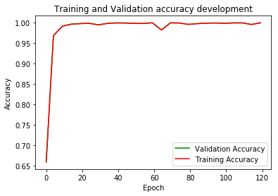

```
Model saved as  ./larenet_6
```

```python
# This code cell contains code for training the model and
# evaluating model during training with training and validation data.
from sklearn.model_selection import StratifiedShuffleSplit
from sklearn.utils import shuffle
import pickle
# For progress bar
from ipywidgets import FloatProgress, Text
from IPython.display import display
# Needed for timing
import time

# Set to True if you want to train the model as training will
# take a long time it's better to load model from file.
TRAIN_MODEL = True
EPOCHS = 120  # It is estimated that with GTX 1080i one epoch takes about 60s
BATCH_SIZE = 512 * 1  # Reduce batch size if you run out of memory
VALIDATION_INTERVALL = 5  # Defines how often accuracy is validated

if TRAIN_MODEL:
    # Initialize progress bar
    # TODO: ipywidgets progress bar could be replaced with tqdm-progress bar
    progressbar_batch = FloatProgress(min=0, description='Batch')
    progressbar_epoch = FloatProgress(min=0, description='Epoch')
    infotext = Text()
    display(progressbar_batch)
    display(progressbar_epoch)
    display(infotext)

    # Training the model
    # Store validation accuray, training accuracy and epoch # into these lists
    validationaccuracylog, trainingaccuracylog, epochlog = [], [], []
    validation_accuracy, training_accuracy = 0, 0

    infotext.value = "Opening Session..."
    saver = tf.train.Saver()
    with tf.Session() as sess:
        start = time.time()
        progressbar_epoch.max = EPOCHS
        sess.run(tf.global_variables_initializer())
        num_examples = len(X_train)
        num_batches = num_examples/BATCH_SIZE
        progressbar_batch.max = num_batches
        print("Training data is divided into {:d} batches.".format(int(num_batches)))
        infotext.value = "Training..."
        for i in range(EPOCHS):
            X_train, y_train = shuffle(X_train, y_train)
            nbatch = 0
            progressbar_batch.value = 0
            for offset in range(0, num_examples, BATCH_SIZE):
                end = offset + BATCH_SIZE
                nbatch += 1
                progressbar_batch.value = nbatch
                batch_x, batch_y = X_train[offset:end], y_train[offset:end]
                sess.run(training_operation, feed_dict={x: batch_x, y: batch_y, keep_prob: 0.50})
            if (i + 1)  % VALIDATION_INTERVALL == 0 or i == 0: # Validate on defined intervals
                infotext.value  = "Validating"
                validationaccuracylog.append(evaluate(X_valid, y_valid))
                trainingaccuracylog.append(evaluate(X_train, y_train))
                epochlog.append(int(i))
            progressbar_epoch.value += 1
            infotext.value = "Last validation at EPOCH {} with acc. {:.3f}.".format(epochlog[-1] + 1,
                                                                                    validationaccuracylog[-1])
        stop = time.time()
        infotext.value = "Training is Finished"
        print("Training took totally {:.0f} seconds for {} epochs \
and on average it took {:.2f} seconds / epoch\n".format(stop-start, EPOCHS, (stop-start)/EPOCHS))
        print("Final training accuracy is {:.3f}".format(trainingaccuracylog[-1]))
        print("Final validation accuracy is {:.3f}".format(validationaccuracylog[-1]))
        plt.plot(epochlog, validationaccuracylog,  'g-', label='Validation Accuracy')
        plt.plot(epochlog, trainingaccuracylog,    'r-', label="Training Accuracy")
        plt.legend()
        plt.xlabel('Epoch')
        plt.ylabel('Accuracy')
        plt.title("Training and Validation accuracy development")
        plt.show()
        model_file_name = './larenet_6'
        saver.save(sess, model_file_name)
        tf.train.export_meta_graph(model_file_name + '.meta')
        print("Model saved as ", model_file_name)
```

```python
# Load model from file and run evaluation for training, validation and test sets
import tensorflow as tf
import numpy as np

# Preprocess data
print("Preprocessing  data...  ", end='')
X_train = preprocess_tensor(X_train)
X_valid = preprocess_tensor(X_valid)
X_test  = preprocess_tensor(X_test)
print("OK!")

# Print simple statistics of data
print("Statistics of data sets")
print("  Training data   ", X_train.shape)
print("  Validation data ", X_valid.shape)
print("  Testing data    ", X_test.shape)

# BATCH_SIZE = 1024  # You can use batch size setting from "training"-cell
with tf.Session() as sess:
    # Import trained model from disk
    print("Importing model...  ", end='')
    loader = tf.train.Saver()
    loader.restore(sess, "./larenet_6")
    print("OK!")

    # Run model evaluation with train, validation and test sets
    print("Evaluating model...  ", end='')
    training_accuracy = evaluate(X_train, y_train)
    validation_accuracy = evaluate(X_valid, y_valid)
    test_accuracy = evaluate(X_test, y_test)
    print("OK!")

    # Print statistics for training, validation and test sets
    print("\n\nThese results are calculated by using saved model.")
    print("  Training Accuracy   = {:.3f}".format(training_accuracy))
    print("  Validation Accuracy = {:.3f}".format(validation_accuracy))
    print("  Test Accuracy       = {:.3f}".format(test_accuracy))
```

```
Preprocessing  data...  OK!
Statistics of data sets
  Training data    (1750289, 32, 32, 1)
  Validation data  (14116, 32, 32, 1)
  Testing data     (12630, 32, 32, 1)
Importing model...  OK!
Evaluating model...  OK!


These results are calculated by using saved model.
  Training Accuracy   = 0.999
  Validation Accuracy = 0.999
  Test Accuracy       = 0.977
```

## Step 3: Test a Model on New Images

To give yourself more insight into how your model is working, download at least five pictures of German traffic signs from the web and use your model to predict the traffic sign type.

You may find `signnames.csv` useful as it contains mappings from the class id (integer) to the actual sign name.

### Load and Output the Images

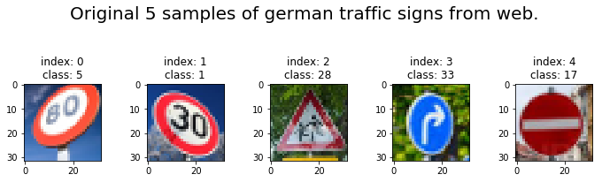

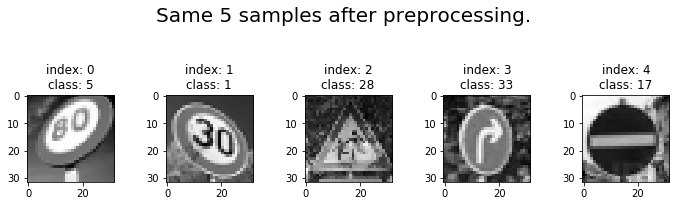

```python
# Load the images and plot them here.
import tensorflow as tf

import os, fnmatch
from scipy import misc
import numpy as np

test_img_path = "./test_images/" # Test images are stored here

X_test_images, y_test_images = [], []
# Load image filenames and ClassIds from CSV file
with open(test_img_path + "test_images.csv", newline='') as csvfile:
    headers = next(csvfile, None)
    for row in csv.reader(csvfile, delimiter=','):
        #sign_names[int(row['ClassId'])] = row['SignName']
        img = misc.imread(test_img_path + row[0])
        shape = img.shape
        # Ensure that image has correct shape
        assert(shape == (32, 32, 3)), "Shape of image file {} is {}, but (32, 32, 3) was expected".format(row[0], shape)
        X_test_images.append(img)
        y_test_images.append(row[1])
    X_test_images = np.array(X_test_images)
    y_test_images = np.array(y_test_images)

# Show loaded test images from disk
nsamples = len(X_test_images)
# Show original images
show_samples(range(0, nsamples), X_test_images, y_test_images, title="Original 5 samples of german traffic signs from web.")
# Preprocess and show preprocessed images
X_test_images = preprocess_tensor(X_test_images)
show_samples(range(0, nsamples), X_test_images, y_test_images, title="Same 5 samples after preprocessing.")
```

Few comments about these german traffic signs Comments are per image index

1. For human it seems to be obvious that it is 80km/h speed limit sign, but when you look closely the upper part of the eight is bit blurred
2. Looks clear, shouldn't be problem
3. Some reflections on sign, may pose a problem
4. Clear sign, shouldn't be problem
5. Clear sign, shouldn't be problem

### Predict the Sign Type for Each Image

```python
### Run the predictions here and use the model to output the prediction for each image.
### Make sure to pre-process the images with the same pre-processing pipeline used earlier.
### Feel free to use as many code cells as needed.

import tensorflow as tf
results = None
with tf.Session() as sess:
    # saver = tf.train.import_meta_graph('./larenet_6.meta')
    saver = tf.train.Saver()
    saver.restore(sess, "./larenet_6")
    #init = tf.global_variables_initializer()
    #sess.run(init)
    print("Session restored\n")
    # result is array of [predicted labels, ground-truth labels]
    results = sess.run([tf.argmax(logits, 1), tf.argmax(one_hot_y, 1)],
                      feed_dict={x: X_test_images, y: y_test_images, keep_prob:1.0})
    print("Index, Truth, Prediction, Description (Predicted)")
    for i, pred in enumerate(results[0]):
        print("{:5d}  {:5d}  {:10d}  {:15s}".format(i, int(y_test_images[i]), pred, sign_names[pred]))
```

```
Session restored

Index, Truth, Prediction, Description (Predicted)
    0      5           5  Speed limit (80km/h)
    1      1           1  Speed limit (30km/h)
    2     28          28  Children crossing
    3     33          33  Turn right ahead
    4     17          17  No entry
```

### Analyze Performance

```python
# Calculate the accuracy for these 5 new images.
# For example, if the model predicted 1 out of 5 signs correctly, it's 20% accurate on these new images.

corr = 0  # counter for correct predictions
for pred, gt in zip(results[0], results[1]):
    corr += pred == gt  # If results are equal it will return 1 and therefore increases our counter
print("Model predicted {} signs correctly out of {}".format(corr, len(results[0])))
print("Prediction accuracy is {}% for 5 test images downloaded from web".format(100*corr/len(results[0])))
```

```
Model predicted 5 signs correctly out of 5
Prediction accuracy is 100.0% for 5 test images downloaded from web
```

#### Performance compared to training, validation and test sets

With a limited sample size(5) it is not feasible to compare performance to training, validation and test sets performance. Especially now when all traffic signs were predicted correctly. More insight could be got if we choose difficult images into our sample set. Then we could understand better is our model generalizing unseen data. The reason why we shouldn't make any statistical judgements by using this 5-images data set is that the uncertainty is high. For instance if we got 4 out of 5 images right then the accuracy would be 80%. In otherwords i sample constitues 20% of final accuracy reading.

Let's assume that we would have bigger test set such like the size of the test set used earlier in this notebook. Then if test accuracy is 100%, which is actually higher than validation accuracy, we could conclude following: model generalizes perfectly on unseen data... But somehow that wouldn't make sense to use test which gives us 100% accuracy. Perhaps we're missing something? Is it that our test set don't represent world correcly? Do it only have traffic signs which are easy to detect? Or perhaps some other reason.

If accuracy on test set is lower than on training and validation sets, then we can say that our model is overfitting. On the otherhand if accuracy is about same than training and validation sets we can say that model is generalizing as well as it can on unseen data.

It is also good to compare training and test set accuracies to human level performance in order to understand how model is performing.

### Output Top 5 Softmax Probabilities For Each Image Found on the Web

For each of the new images, print out the model's softmax probabilities to show the **certainty** of the model's predictions (limit the output to the top 5 probabilities for each image). [`tf.nn.top_k`](https://www.tensorflow.org/versions/r0.12/api_docs/python/nn.html#top_k) could prove helpful here.

`tf.nn.top_k` will return the values and indices (class ids) of the top k predictions. So if k=3, for each sign, it'll return the 3 largest probabilities (out of a possible 43) and the correspoding class ids.

Take this numpy array as an example. The values in the array represent predictions. The array contains softmax probabilities for five candidate images with six possible classes. `tk.nn.top_k` is used to choose the three classes with the highest probability:

```python
# Support functions
import numpy as np
import matplotlib.pyplot as plt




def create_propability_bar(propabilities, classids, mapping):
    """
    This functions creates a horizontal bar graph of propabilities.

    Parameters
    ----------
    propabilities: list
        List of propabilities
    classids : list
        Corresponding list of propabilities classids
    mapping : dictionary
        Dictionary where key is class id and value it's description

    Returns
    -------
    graph
        Propabilites plotted in descending order
    """
    y_position = list(range(0, len(propabilities)))
    y_position.reverse()
    graph = plt.barh(bottom=y_position,
                     width=propabilities,
                     tick_label=map_classids_to_names(classids, mapping))
    return graph


def show_topk(X, y, topk, mapping, nmax=25, title=None):
    """
    This functions shows test images with corresponding ClassIds.

    Parameters
    ----------
    X: numpy array
        4D tensor array where dimensions are
        (N, img width, img height, channels)
    y : numpy array
        1D list of corresponding class Ids of X
    topk : numpy array
        2D list of topk propabilities and class ids of the test set
    mapping : dictionary
        Dictionary where key is class id and value it's description
    nmax : integer
        Number of maximum data points(images) to be analyzed
    """
    fig = plt.figure(figsize=(15, 20)) # Plot size in inches
    fig.suptitle(title, fontsize=20, y=1.08)
    ncols = 2  # Number of columns in plot
    nrows = 15 # Number of rows in plot
    for i, props in enumerate(zip(topk[0], topk[1])):
        # subplot(nrows, ncols, plot_number)
        # Calculate plot numbers so that image is shown on top and bar plots under images
        img_plot_number = 1 + (int(i / (ncols)) * ncols*2) + i % ncols
        bar_plot_number = img_plot_number + ncols

        a = fig.add_subplot(nrows, ncols, img_plot_number)
        # Use sign description as title
        a.set_title(sign_names[y[i]])
        plt.imshow(X[i].squeeze(), cmap="gray")
        b = fig.add_subplot(nrows, ncols, bar_plot_number)
        create_propability_bar(props[0], props[1], sign_names)
        #print(props[0], props[1])
        #b.set_title("Propabilities")
    fig.tight_layout(h_pad=0.5)
    plt.show()
```

```python
# Predict class of 5 german traffic sign here.
# Analysis is in following code cells

result = None
with tf.Session() as sess:
    #saver = tf.train.import_meta_graph('./larenet_6.meta')
    saver = tf.train.Saver()
    saver.restore(sess, "./larenet_6")
    #init = tf.global_variables_initializer()
    #sess.run(init)
    print("Session restored")
    result = sess.run([tf.argmax(logits, 1), tf.argmax(one_hot_y, 1), tf.nn.top_k(tf.nn.softmax(logits), k=5)],
                      feed_dict={x: X_test_images, y: y_test_images, keep_prob:1.0})
    # result array: 0 = predicted class, 1 = top_k values, 2 = ground truth
```

```
Session restored
```

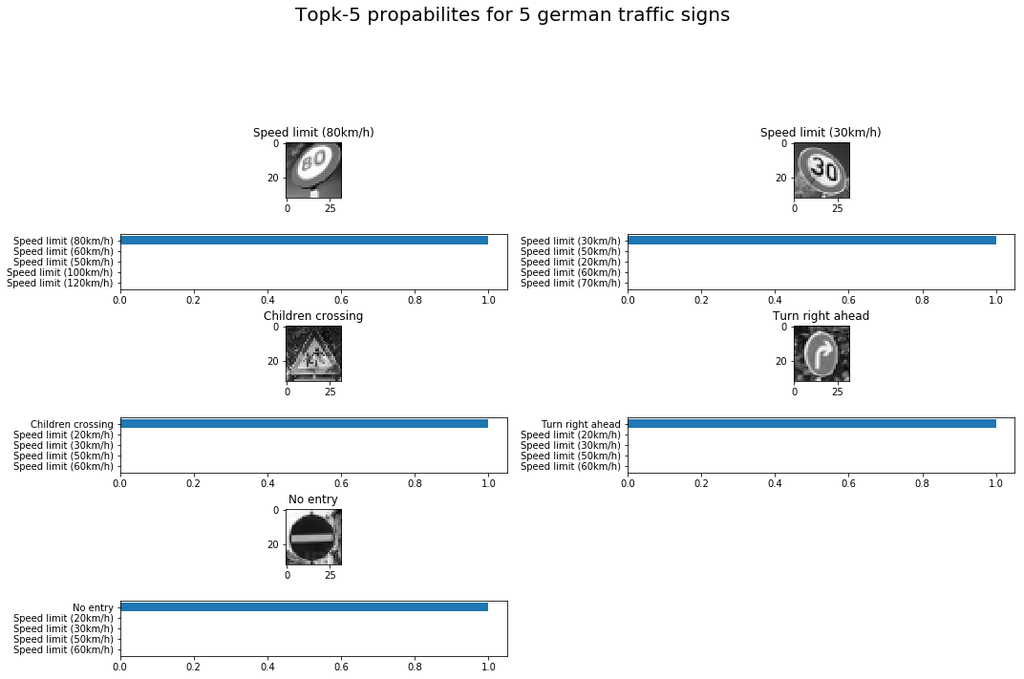

```
And for reference topk softmax propabilites in raw print are:


TopKV2(values=array([[  9.99983907e-01,   1.34169068e-05,   1.35610276e-06,
          1.33636740e-06,   5.69871039e-10],
       [  1.00000000e+00,   1.28361011e-36,   0.00000000e+00,
          0.00000000e+00,   0.00000000e+00],
       [  1.00000000e+00,   0.00000000e+00,   0.00000000e+00,
          0.00000000e+00,   0.00000000e+00],
       [  1.00000000e+00,   0.00000000e+00,   0.00000000e+00,
          0.00000000e+00,   0.00000000e+00],
       [  1.00000000e+00,   0.00000000e+00,   0.00000000e+00,
          0.00000000e+00,   0.00000000e+00]], dtype=float32), indices=array([[ 5,  3,  2,  7,  8],
       [ 1,  2,  0,  3,  4],
       [28,  0,  1,  2,  3],
       [33,  0,  1,  2,  3],
       [17,  0,  1,  2,  3]], dtype=int32))
```

```python
# Illustrate topk-5 propabilities
pred = result[0]
y_ = result[1]
topk = result[2]

show_topk(X_test_images, y_, topk, sign_names, title="Topk-5 propabilites for 5 german traffic signs")

print("\nAnd for reference topk softmax propabilites in raw print are:\n\n")
print(topk)
```

## Step 4: Visualize the Neural Network's State with Test Images

This Section is not required to complete but acts as an additional excersise for understaning the output of a neural network's weights. While neural networks can be a great learning device they are often referred to as a black box. We can understand what the weights of a neural network look like better by plotting their feature maps. After successfully training your neural network you can see what it's feature maps look like by plotting the output of the network's weight layers in response to a test stimuli image. From these plotted feature maps, it's possible to see what characteristics of an image the network finds interesting. For a sign, maybe the inner network feature maps react with high activation to the sign's boundary outline or to the contrast in the sign's painted symbol.

Provided for you below is the function code that allows you to get the visualization output of any tensorflow weight layer you want. The inputs to the function should be a stimuli image, one used during training or a new one you provided, and then the tensorflow variable name that represents the layer's state during the training process, for instance if you wanted to see what the LeNet lab's feature maps looked like for it's second convolutional layer you could enter conv2 as the tf_activation variable.

For an example of what feature map outputs look like, check out NVIDIA's results in their paper [End-to-End Deep Learning for Self-Driving Cars](https://devblogs.nvidia.com/parallelforall/deep-learning-self-driving-cars/) in the section Visualization of internal CNN State. NVIDIA was able to show that their network's inner weights had high activations to road boundary lines by comparing feature maps from an image with a clear path to one without. Try experimenting with a similar test to show that your trained network's weights are looking for interesting features, whether it's looking at differences in feature maps from images with or without a sign, or even what feature maps look like in a trained network vs a completely untrained one on the same sign image.

[figure not shown]

Your output should look something like this (above)

```python
### Visualize network's feature maps

def outputFeatureMap(image_input, tf_activation, activation_min=-1, activation_max=-1 ,plt_num=1, title=None):
    """
    Visualizes network's activation maps.

    Here make sure to preprocess your image_input in a way your network expects
    with size, normalization, ect if needed

    Parameters
    ----------
    image_input: numpy array
        the test image being fed into the network to produce the feature maps.
        Should be 4D tensor which contains single image
    tf_activation : tf variable
        should be a tf variable name used during your training procedure that
        represents the calculated state of a specific weight layer
    activation_min : integer
        can be used to view the activation contrast in more detail, by default
        matplot sets min and max to the actual min and max values of the output
    activation_max : integer
        can be used to view the activation contrast in more detail, by default
        matplot sets min and max to the actual min and max values of the output
    plt_num : integer
        used to plot out multiple different weight feature map sets on the same
        block, just extend the plt number for each new feature map entry
    """

    #image_input =
    # Note: x should be the same name as your network's tensorflow data
    #       placeholder variable
    # If you get an error tf_activation is not defined it maybe having
    # trouble accessing the variable from inside a function
    activation = tf_activation.eval(session=sess,feed_dict={x : image_input})
    featuremaps = activation.shape[3]
    fig = plt.figure(plt_num, figsize=(15,15))
    fig.suptitle(title, fontsize=20, y=1.00)
    for featuremap in range(featuremaps):
        plt.subplot(6,8, featuremap+1) # sets the number of feature maps to show on each row and column
        plt.title('FeatureMap ' + str(featuremap)) # displays the feature map number
        if activation_min != -1 & activation_max != -1:
            plt.imshow(activation[0,:,:, featuremap], interpolation="nearest",
                       vmin =activation_min, vmax=activation_max, cmap="gray")
        elif activation_max != -1:
            plt.imshow(activation[0,:,:, featuremap], interpolation="nearest",
                       vmax=activation_max, cmap="gray")
        elif activation_min !=-1:
            plt.imshow(activation[0,:,:, featuremap], interpolation="nearest",
                       vmin=activation_min, cmap="gray")
        else:
            plt.imshow(activation[0,:,:, featuremap], interpolation="nearest", cmap="gray")
```

```
Restoring session... OK!
Get tensors for visualization...  OK!
Visualizing tensors...  OK!
```

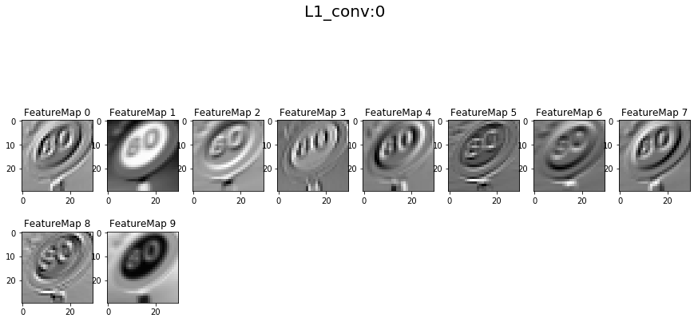

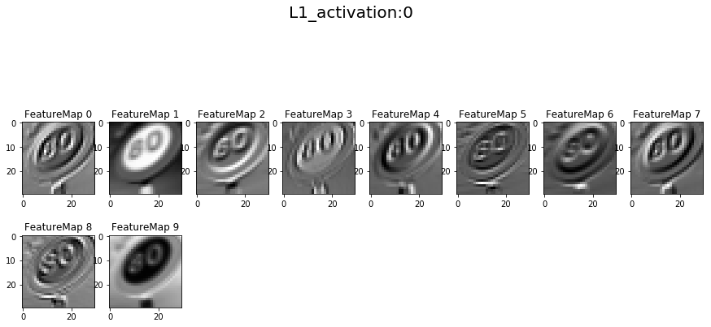

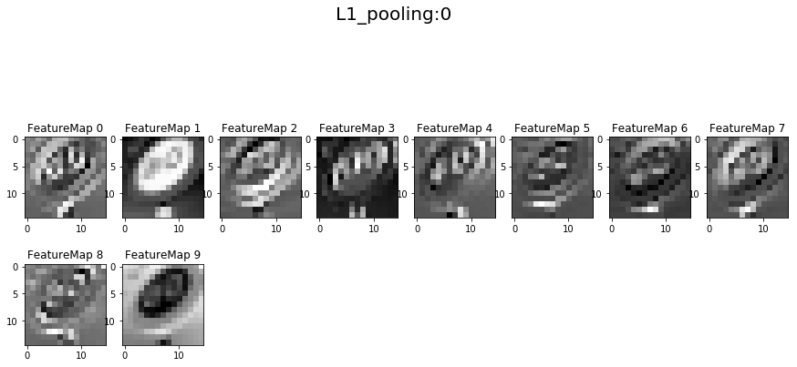

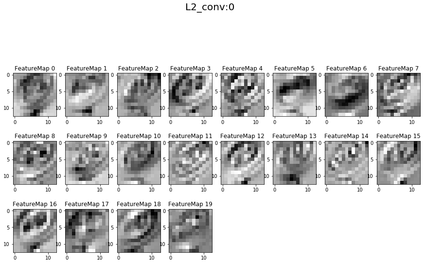

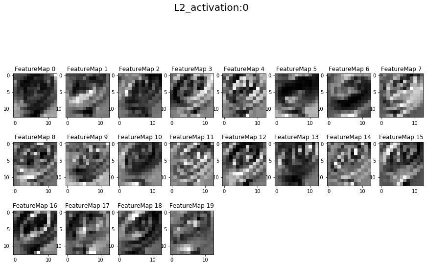

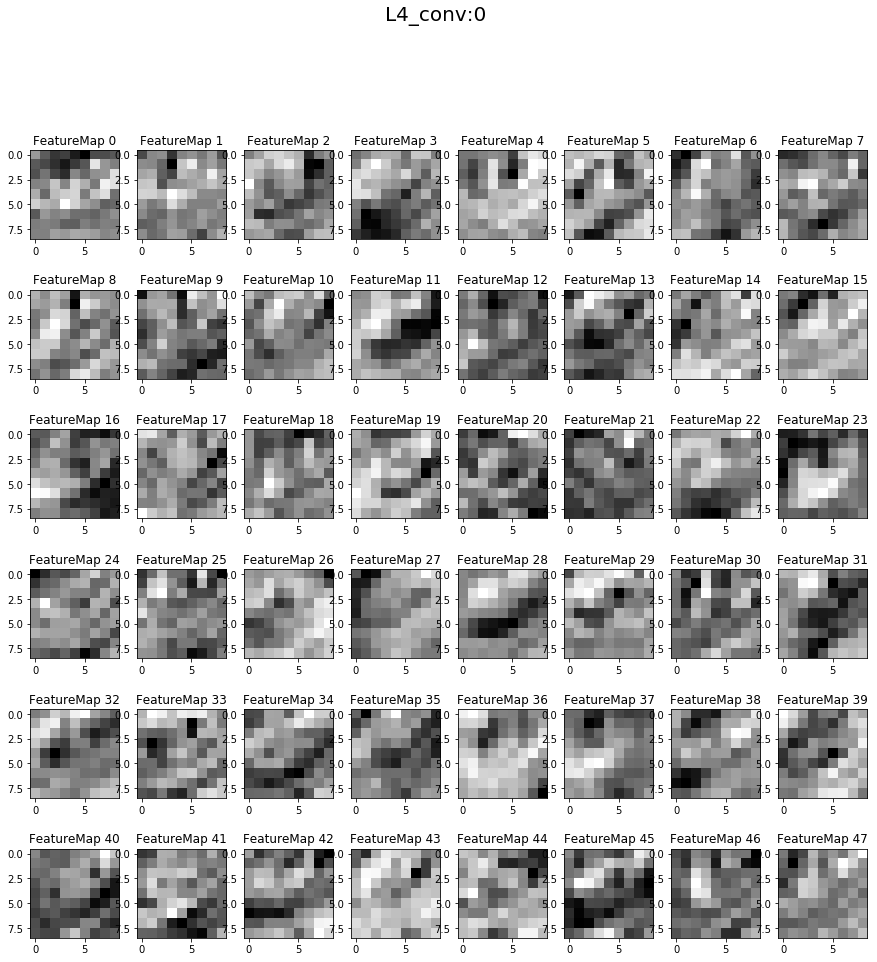

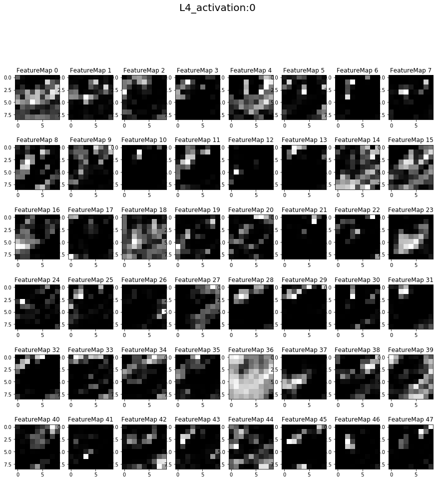

```python
# In this code cell we visualize tensors

with tf.Session() as sess:
    print("Restoring session... ", end='')
    saver = tf.train.Saver()
    saver.restore(sess, "./larenet_6")
    print("OK!")

    # Define here tensor names you want to visualize
    # Pyplot can't show more than 48 plots so limit to layers which depth is less than 49
    tensor_names = ["L1_conv:0", "L1_activation:0", "L1_pooling:0",
                    "L2_conv:0", "L2_activation:0",
                    "L4_conv:0", "L4_activation:0"]


    # Get tensors here in separate loop as it seems that if we get
    # tensors directly in visualization loop we got errors
    print("Get tensors for visualization...  ", end='')
    tensors = []
    for name in tensor_names:
        tensors.append(sess.graph.get_tensor_by_name(name))
    print("OK!")

    print("Visualizing tensors...  ", end='')
    for i, tensor in enumerate(tensors):
        #tensor_to_visualize = sess.graph.get_tensor_by_name(x)
        outputFeatureMap(X_test_images[:1], tensor,
                         activation_min=-1, activation_max=-1,
                         plt_num=i+1, title=tensor.name)
    print("OK!")
```

### Question 9

Discuss how you used the visual output of your trained network's feature maps to show that it had learned to look for interesting characteristics in traffic sign images

**Answer:** I did analysis for Layer 1 convolution and activation and saw that there is indeed very interesting features extractred from the input image. By using this tool it would be good to check that network can successfully extract features from images.

For example the layer 1 convolution looks quite stunning.

[figure not shown]

L1 convolution

[figure not shown]

> **Note**: Once you have completed all of the code implementations and successfully answered each question above, you may finalize your work by exporting the iPython Notebook as an HTML document. You can do this by using the menu above and navigating to \n", "**File -> Download as -> HTML (.html)**. Include the finished document along with this notebook as your submission.

### Project Writeup

Once you have completed the code implementation, document your results in a project writeup using this [template](https://github.com/udacity/CarND-Traffic-Sign-Classifier-Project/blob/master/writeup_template.md) as a guide. The writeup can be in a markdown or pdf file.